# Dr Jordan Harold

Applied cognitive psychologist // climate change // statistical cognition

2021-08-10

# About me

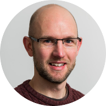

I am interested in how individuals interpret scientific evidence about climate change, and how evidence can be communicated to support societal decision-making. A key aspect of my current work is understanding the interlinkages between people’s cognitions and behaviours and policy responses to climate change that would enable societal transformation.

As an applied cognitive psychologist at the [University of East Anglia](https://people.uea.ac.uk/jordan_harold) and [Tyndall Centre for Climate Change Research](https://www.tyndall.ac.uk/people/jordan-harold), I connect insights about how people think and make decisions with real-world practical applications. I employ a range of methods in my work, including experiments, eye-tracking, decision-making tasks, surveys and interviews.

Through my recent work with the Intergovernmental Panel on Climate Change (IPCC), I have supported the visual communications design of the [IPCC Climate Change 2021 - The Physical Science Basis](https://www.ipcc.ch/report/ar6/wg1/), and the Special Reports on [Global Warming of 1.5<sup>o</sup>C](https://www.ipcc.ch/sr15/) and [Climate Change and Land](https://www.ipcc.ch/srccl/) (as a drafting author to the Summaries for Policymakers).

# Contact me

Email: Jordan.Harold [@] uea.ac.uk | Twitter: @ jordanharold

# Publications

## Journal articles

Harold, J., Lorenzoni, I., Shipley, T. F., & Coventry, K. R. (2019). Communication of IPCC visuals: IPCC authors’ views and assessments of visual complexity. *Climatic Change*. https://doi.org/10.1007/s10584-019-02537-z

Harold, J., Lorenzoni, I., Shipley, T. F., & Coventry, K. R. (2016). Cognitive and psychological science insights to improve climate change data visualization. *Nature Climate Change*, *6*, 1080–1089. https://doi.org/10.1038/NCLIMATE3162

## Other publications

IPCC (2021). Summary for Policymakers. In: *Climate Change 2021: The Physical Science Basis. Contribution of Working Group I to the Sixth Assessment Report of the Intergovernmental Panel on Climate Change* [V. Masson-Delmotte, P. Zhai, A. Pirani, S. L. Connors, C. Péan, S. Berger, N. Caud, Y. Chen, L. Goldfarb, M. I. Gomis, M. Huang, K. Leitzell, E. Lonnoy, J.B.R. Matthews, T. K. Maycock, T. Waterfield, O. Yelekçi, R. Yu and B. Zhou (eds.)]. Cambridge University Press. In Press. http://tiny.cc/IPCC_AR6_WG1_SPM

Drafting author to the SPM

IPCC (2019). Summary for Policymakers. In: *Climate Change and Land: an IPCC special report on climate change, desertification, land degradation, sustainable land management, food security, and greenhouse gas fluxes in terrestrial ecosystems* [P.R. Shukla, J. Skea, E. Calvo Buendia, V. Masson-Delmotte, H.- O. Pörtner, D. C. Roberts, P. Zhai, R. Slade, S. Connors, R. van Diemen, M. Ferrat, E. Haughey, S. Luz, S. Neogi, M. Pathak, J. Petzold, J. Portugal Pereira, P. Vyas, E. Huntley, K. Kissick, M. Belkacemi, J. Malley, (eds.)]. In press. http://tiny.cc/IPCC_Land_SPM

Drafting author to the SPM

Harold, J., Coventry, K. R., Visman, E., Diop, I. S., Kavonic, J., Lorenzoni, I., Jack, C. & Warnaars, T. (2019). *Approaches to communicating climatic uncertainties with decision-makers.* Guide for Future Climate for Africa, published by Climate and Development Knowledge Network. https://futureclimateafrica.org/wp-content/uploads/2019/09/approaches-to-communicating-climatic-uncertainties-with-decision-makers_final.pdf

IPCC (2018). Summary for Policymakers. In: *Global Warming of 1.5°C. An IPCC Special Report on the impacts of global warming of 1.5°C above pre-industrial levels and related global greenhouse gas emission pathways, in the context of strengthening the global response to the threat of climate change, sustainable development, and efforts to eradicate poverty* [Masson-Delmotte, V., P. Zhai, H.-O. Pörtner, D. Roberts, J. Skea, P.R. Shukla, A. Pirani, W. Moufouma-Okia, C. Péan, R. Pidcock, S. Connors, J.B.R. Matthews, Y. Chen, X. Zhou, M.I. Gomis, E. Lonnoy, T. Maycock, M. Tignor, and T. Waterfield (eds.)]. World Meteorological Organization, Geneva, Switzerland, 32 pp. http://tiny.cc/IPCC_SR15_SPM

Drafting author to the SPM

Harold, J. (2017). *How IPCC graphics could be made more accessible.* Guest post for Carbon Brief. https://www.carbonbrief.org/guest-post-how-ipcc-graphics-could-be-made-more-accessible

Harold, J., Lorenzoni, I., Coventry, K. R. & Minns, A. (2017). *Enhancing the accessibility of climate change data visuals. Recommendations to the IPCC and guidance for researchers.* Report published by the Tyndall Centre for Climate Change Research, Norwich, UK. https://www.tyndall.ac.uk/datavisuals

Harold, J., Coventry, K. R., Lorenzoni, I., & Shipley, T.F. (2016). *Interpreting data graphics: visual clutter and comprehension of climate change.* Poster presentation at the EARLI Special interest Group for ‘Text and Graphics Comprehension’ (SIG2), 12th July 2016, Geneva, Switzerland. https://easychair.org/smart-program/EARLISIG22016/2016-07-12.html#talk:22982

Harold, J., Coventry, K. R., Lorenzoni, I., & Shipley, T. F. (2015). Making Sense of Time-Series Data: How Language Can Help Identify Long-Term Trends. In Noelle, D. C., Dale, R., Warlaumont, A. S., Yoshimi, J., Matlock, T., Jennings, C. D., & Maglio, P. P. (Eds.) *Proceedings of the 37th Annual Meeting of the Cognitive Science Society.* Austin, TX: Cognitive Science Society; pp 872-77. https://mindmodeling.org/cogsci2015/papers/0157/paper0157.pdf